# コミュニティバス路線上の人口密度の可視化

射水市の例

[岩田真一郎](https://shinichiro-iwata.github.io/)（ [神奈川大学経済学部](https://www.econ.kanagawa-u.ac.jp/)）

2022-06-11作成，2024-03-25改訂

# 1 目的

人口密度を加えたメッシュデータ（地図で見る統計）にコミュニティバス路線（国土数値情報）を重ねて，人口密度がバス事業成立の条件を満たしているかを可視化．

- 地方民間バス路線の廃止に伴い，コミュニティバスや乗合タクシーなどの形で自治体がバス事業を引き継ぐケースが見受けられる．
- バス事業を成立（1便／1時間）するには，30人／ha程度の人口密度が求められる．
  - 今回は500mメッシュ統計を利用．30人／haはメッシュ内750人程度に該当．
  - 例として，富山県射水市のコミュニティバスを取り上げる．
    - [射水市コミュニティバス「きときとバス」](https://www.city.imizu.toyama.jp/guide/svGuideDtl.aspx?servno=640)（アクセス日：2022/05/06）
    - 参考文献：日立市交通交通協議（2015年）（アクセス日：2022/05/07）
    - （⇒[日立市地域公共交通網形成計画](https://www.city.hitachi.lg.jp/machizukuri_kankyo/kotsu_doro/1002847/1002851.html)（アクセス日：2024/03/25））

利用ライブラリ：`sf`，`tidyverse`, `MetBrewer`

```r
library(sf)
library(tidyverse)

#Hokusai2カラーパレット利用のため（好み）
library(MetBrewer)
```

# 2 バス路線の可視化

**富山県**

- [国土数値情報ダウンロードサイト](https://nlftp.mlit.go.jp/ksj/) > 行政区域（ポリゴン） > 富山県 > 令和3年
  - シェープファイルの読込（`read_sf`）．`Toyama_map`と名付ける．

```r
Toyama_map <-
  read_sf("N03-20210101_16_GML/N03-20210101_16_GML/N03-21_16_210101.shp")
```

**射水市**

- パイプ演算子（`%>%`）を使い`Toyama_map`から「射水市」（`Imizushi_shi_map`と名付ける）を選別（`filter`）．
  - 射水市の場所を知らない人のために，その場所（ポリゴン）を富山県の地図上に示す．境界内（`fill`）は白．境界線は太く（`linewidth`）する．

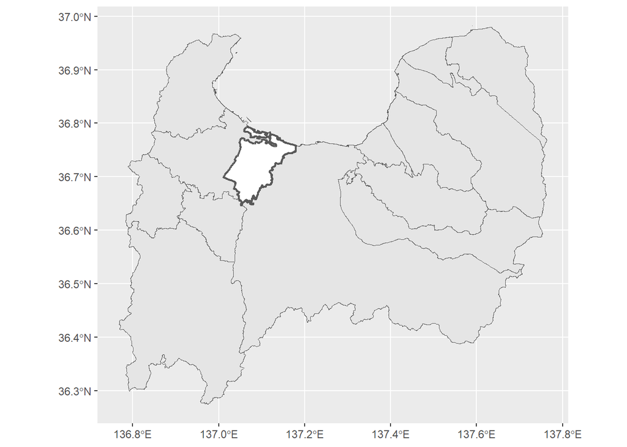

```r
#射水市の選別
Toyama_map %>%
  filter(N03_004=="射水市") ->
  Imizu_shi_map

#射水市の地図をImizuと命名
Imizu <-
  geom_sf(data=Imizu_shi_map, fill="white",
          linewidth=0.8)

#射水市の可視化
ggplot()+
  geom_sf(data=Toyama_map)+
  Imizu
```

**コミュニティバス路線**

- [国土数値情報ダウンロードサイト](https://nlftp.mlit.go.jp/ksj/) > バスルート（ライン） > 富山県 > 平成23年（のみ掲載，アクセス日：2022/05/06）[^1]
  - このデータは日本語が文字化け．オプション（`encoding="cp932"`）で文字化けを防ぐ．

```r
busline <-
  read_sf("N07-11_16_GML/N07-11_16.shp",
          options = c("encoding=CP932"),
          crs="EPSG:6668")
```

**注意**：`ggplot()+geom_sf(data=busline)`と指示してもエラーが出る．

- バスルート（ライン）ファイルは`Geometry type: MULTILINESTRING`で`Dimension:XYM`のため地図に表せない模様（ここでは確認しないが`head(busline)`で`XYM`であることが確認できる）．
  - `M`が3つ目の次元．2次元（`Dimension:XY`）にするために`st_xm()`関数を使用して，`M`を削除（`head(busline)`で再確認すると，`Dimension:XY`に変更される）．

```r
#2次元に変更
busline <- st_zm(busline)
```

- パイプ演算子（`%>%`）を使い，事業者（`N07_002`）の「射水市」を抜き出し，`busline_Imizu`と名付ける．
  - バス路線（`linetype`）を破線（`dashed`）で表現．
  - その他の形状：[linetype](https://ggplot2.tidyverse.org/articles/ggplot2-specs.html#lines)参照．

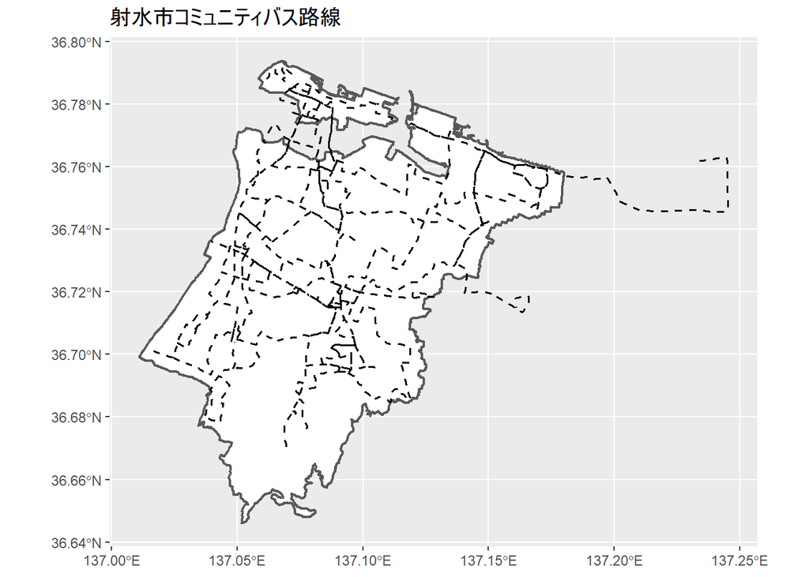

```r
#射水市コミュニティバスの選別
busline %>%
  filter(N07_002=="射水市") ->
  busline_Imizu

#射水市コミュニティバス路線の地図をImizu_busと命名
Imizu_bus <-
  geom_sf(data=busline_Imizu,
          linewidth=0.6, linetype="dashed")

#路線の可視化
ggplot()+
  Imizu+
  Imizu_bus+
  ggtitle("射水市コミュニティバス路線")
```

**バス停留所**

- [国土数値情報ダウンロードサイト](https://nlftp.mlit.go.jp/ksj/) > バス停留所（ポイント） > 富山県 > 平成22年（のみ掲載，アクセス日：2022/05/06）[^2]

```r
busstop <-
  read_sf("P11-10_16_GML/P11-10_16-jgd-g_BusStop.shp",
          crs="EPSG:6668")
```

- 射水市コミュニティバスのバス停のみ抜き出す．バス路線を運営する事業者名（コミュニティバスは自治体名）が`P11_003_1`に記されている．ただし，バス停が民間バスのバス停である場合もある．
  - このため，`P11_003_1==射水市`と指定しても，不十分な数のバス停しか抜き出せない．
  - ここでは，`str_detect()`を使い，`P11_003_1`列に「射水市」を含む文字列があればすべて抜き出すように指示．
    - [行の選択 - filter関数](https://kazutan.github.io/kazutanR/hands_on_170730/filter.html)（アクセス日：2022/06/09）参考．

```r
#射水市コミュニティバスのバス停の選別
busstop %>%
  filter(str_detect(P11_003_1, "射水市")) ->
  busstop
```

- ポイントデータはデフォルトが黒丸．枠と枠内の色を変えるため，`shape`の`21`（円）を選び，枠を黒，枠内を白（`fill`）に指定．
  - その他の形状：[shape](https://ggplot2.tidyverse.org/articles/ggplot2-specs.html#sec:shape-spec)参照．

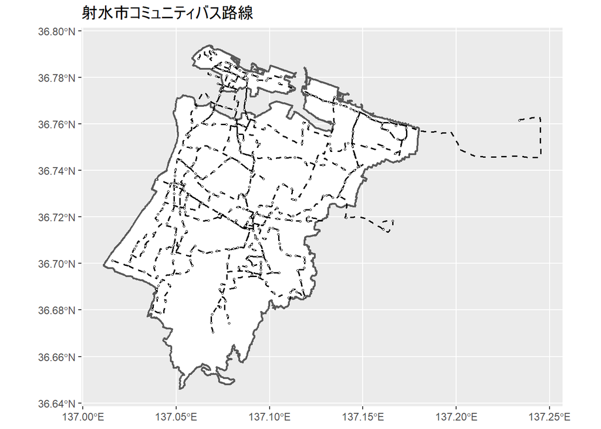

```r
#射水市コミュニティバスのバス停の地図をImizu_busstopと命名
Imizu_busstop <-
  geom_sf(data=busstop, fill="white",
          size=0.5, shape=21)

#バス停の可視化
ggplot()+
  Imizu+
  Imizu_bus+
  Imizu_busstop+
  ggtitle("射水市コミュニティバス路線")
```

**鉄道路線**

地図がわかりやすくなるように，鉄道路線を追加．

- [国土数値情報ダウンロードサイト](https://nlftp.mlit.go.jp/ksj/) > 鉄道（ライン） > 全国 > 令和元年（2019年）

```r
railline <-
  read_sf("N02-19_GML/N02-19_RailroadSection.shp",
                    options = c("encoding=CP932"))
```

**あいの風とやま鉄道**

[あいの風とやま鉄道](https://ainokaze.co.jp/)は富山県内をはしる第三セクター鉄道．北陸新幹線の延伸開業に伴い，JR西日本から経営分離された．

- パイプ演算子（`%>%`）を使い，路線名（鉄道路線の名称，`N02_003`）の「あいの風とやま鉄道」を抜き出し`Ainokaze`と名付ける．
  - 線路（`linetype`）の形状を`f8`）にする．

```r
#あいの風とやま鉄道の選別
railline %>%
  filter(N02_003=="あいの風とやま鉄道線") ->
  Ainokaze

#あいの風とやま鉄道の地図をAinokaze_railwayと命名
Ainokaze_railway <-
  geom_sf(data=Ainokaze, linewidth=0.8,
          linetype="f8")
```

**駅**

あいの風とやま鉄道の名称と駅（呉羽，小杉，越中大門）の位置を表記．

- `annotate()`：地図上の位置を指示．
  - `x`は経度，`y`は緯度に対応．
  - `shape`の`22`（四角）を選び，枠を黒，枠内を白（`fill`）に指定．
  - 緯度経度は地図検索サイト[MapFan](https://mapfan.com/)などから特定．
- `geom_text()`：地図上に文字の挿入を指示．

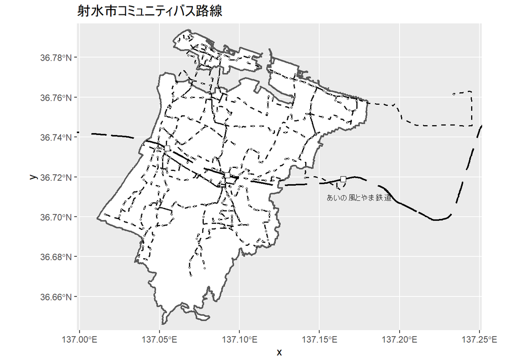

```r
#あいの風とやま鉄道の可視化
ggplot()+
  Imizu+
  Ainokaze_railway+
  Imizu_bus+
  Imizu_busstop+
  annotate("point", x=137.0923306, y=36.7208275,
           fill="white", size=2.5, shape=22)+
  annotate("point", x=137.0547234, y=36.734352,
           fill="white", size=2.5, shape=22)+
  annotate("point", x=137.1648832, y=36.7188936,
           fill="white", size=2.5, shape=22)+
  geom_text(aes(x=137.175, y=36.71), size=3,
              label="あいの風とやま鉄道")+
  coord_sf(xlim=c(137.01, 137.24),
           ylim=c(36.65, 36.79))+
  ggtitle("射水市コミュニティバス路線")
```

# 3 地域メッシュ統計による人口密度の可視化

**境界データ：500メッシュ**

- [統計地理情報システム](https://www.e-stat.go.jp/gis) > 境界データダウンロード > 4次メッシュ（500mメッシュ） > 世界測地系緯度経度・Shapefile > 都道府県で絞込みはコチラ > 富山県
  - 1県あたりシェープ・ファイルが4つほどあるが，今回は下記の2つで射水市をカバーできる．ここでは`mesh_2`と`mesh_4`と名付ける．
  - CRSがJGD2000のため，`st_transform()`で（JGD2011”EPSG:6668”）に揃える．
    - これをしないと，のちほどの作業できない．

```r
mesh_2 <-
  read_sf("HDDSWH5437/MESH05437.shp") %>%
  st_transform("EPSG:6668")

mesh_4 <-
  read_sf("HDDSWH5537/MESH05537.shp") %>%
  st_transform("EPSG:6668")
```

- メッシュの範囲が射水市をカバーしているか確認．
  - 射水市（ポリゴン）の境界枠内を塗りつぶさず（`fill`，`NA`で透明に），境界を青（`color`，色は`#1e4294`），太線（`linewidth`）で示す．

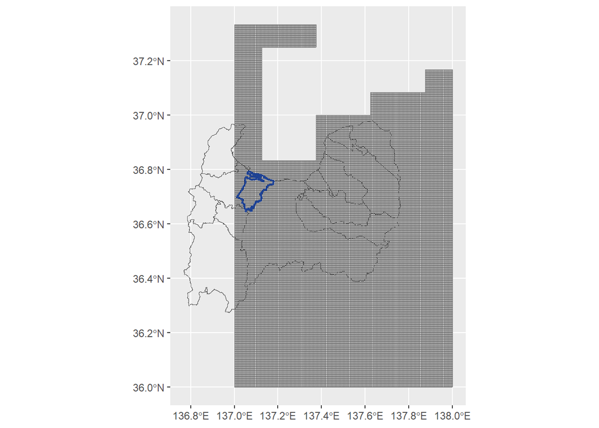

```r
ggplot()+
  geom_sf(data=mesh_2)+
  geom_sf(data=mesh_4)+
  geom_sf(data=Toyama_map, fill="NA")+
  geom_sf(data=Imizu_shi_map, fill="NA",
          color="#1e4294", linewidth=0.8)
```

**統計データ：500mメッシュ**

- e-stat > [統計地理情報システム](https://www.e-stat.go.jp/gis) > 統計データダウンロード > 国勢調査 > 2015年 > 4次メッシュ（500mメッシュ） > その１ 人口等基本集計に関する事項 > 都道府県で絞込みはコチラ > 富山県 > 上記の番号と合致するファイル
- 人口データはテキスト形式．`read.table`で読込．
  - ここでは`Pop_2`と`Pop_4`と名付ける．
  - `header=TRUE`は列名が含まれていることを意味する．仮に列名がなければ`FALSE`．
  - `sep=","`はデータがカンマで区切られていることを意味する．`skip=1`は1番最初の行を削除することを意味する．

```r
Pop_2 <-
  read.table("tblT000847H5437/tblT000847H5437.txt",
                  header=TRUE, sep=",", skip=1,
                  fileEncoding="CP932")
Pop_4 <-
  read.table("tblT000847H5537/tblT000847H5537.txt",
                  header=TRUE, sep=",", skip=1,
                   fileEncoding="CP932")
```

## 3.1 列名の変更

- 境界データと人口データに結合するために`rename()`で`1`列目の列名を`KEY_CODE`に変更．
- `5`列目の列名を「人口総数」として可視化する際に利用．

```r
Pop_2 %>%
  rename(KEY_CODE=1,
         人口総数=5) ->
  Pop_2

Pop_4 %>%
  rename(KEY_CODE=1,
         人口総数=5) ->
  Pop_4
```

- **注意**：境界データの`KEY_CODE`が`character`（文字データ），人口データは`integer`（数データ）のため結合できない．
  - そこで，`Pop_#`の`KEY_CODE`を`character`に変換（`mutate`）する．再び`Pop_#`と名付ける．

```r
Pop_2 %>%
  mutate(KEY_CODE=as.character(KEY_CODE)) ->
  Pop_2
Pop_4 %>%
  mutate(KEY_CODE=as.character(KEY_CODE)) ->
  Pop_4
```

## 3.2 データ結合1

境界データと人口データを結合する．

- 境界データ（`mesh_#`）と人口データ（`Pop_#_1`）を`KEY_CODE`で結合（`left_join`）し，改めて`meshPop_#`と名付ける．

```r
meshPop_2 <-
  left_join(mesh_2, Pop_2, by=c("KEY_CODE"))
meshPop_4 <-
  left_join(mesh_4, Pop_4, by=c("KEY_CODE"))
```

## 3.3 データ結合2

- `meshPop_#`と`Imizu_shi_map`を結合．`st_intersection()`を用いて共通部分を抽出．`mesh_intersection_#`と名付ける．
  - 属性がジオメトリ全体で空間的に一定と仮定しないと[警告](https://github.com/r-spatial/sf/issues/406)が出る？？？．一定（`constant`）と指定．

```r
#Warning（警告）を出さないため
st_agr(meshPop_2)="constant"
st_agr(meshPop_4)="constant"
st_agr(Imizu_shi_map)="constant"

#射水市の地図に人口総数が加わったメッシュデータの完成
mesh_intersection_2 <-
  st_intersection(x=meshPop_2, y=Imizu_shi_map)
mesh_intersection_4 <-
  st_intersection(x=meshPop_4, y=Imizu_shi_map)
```

**データ結合3**

2つの結合データを行（縦）方向に結合．

- 人口総数を階級区分（グループ）などで表現したい場合，データが分かれている（現在，`mesh_intersection_2`と`mesh_intersection_4`）と不都合が生じる場合がある．そこで便宜上，一つにまとめる（`rbind`）．まとめたデータを`Imizu_mesh_pop`と名付ける．

```r
Imizu_mesh_pop <-
  rbind(mesh_intersection_2, mesh_intersection_4)
```

**人口密度の可視化**

行方向に結合したデータ（`Imizu_mesh_pop`）を用いて，500Mメッシュ内の人口総数を地図に表現．

- `scale_fill_met_c()`を利用して，連続変数である`人口総数`を色付け．
  - 欠損値（`NA`）は色が付かない．

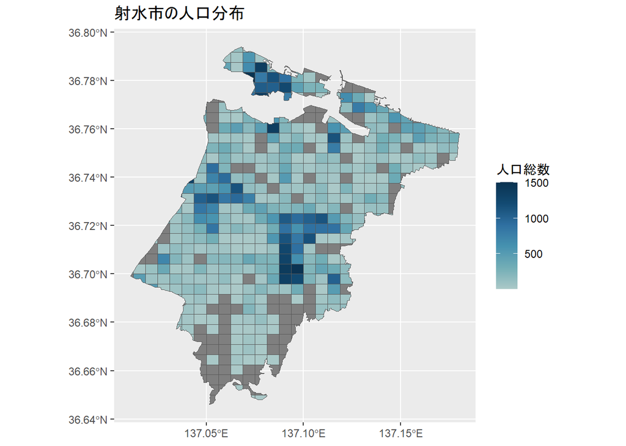

```r
ggplot()+
  geom_sf(data=Imizu_mesh_pop,
          aes(fill=人口総数))+
  scale_fill_met_c("Hokusai2")+
  ggtitle("射水市の人口分布")
```

**人口総数`NA`の扱い**

欠損値（`NA`）は人口が`0`と仮定．

```r
Imizu_mesh_pop %>%
  mutate(人口総数=
           if_else(is.na(人口総数), 0, 人口総数)) ->
  Imizu_mesh_pop
```

# 4 コミュニティバス路線と人口密度の可視化

これまで作成してきた地図を重ねて，目的の地図を完成する．

- バスの採算性は30／ha．500メッシュのため25倍の大きさ．1マスのメッシュ内に750人必要．人口を250人で区切る（`my_breaks`）．
- `labs`は判例の表記の変更のために利用．`X=""`，`y=""`を加えないと，横軸と縦軸にそれぞれ`x`，`y`と表記される．

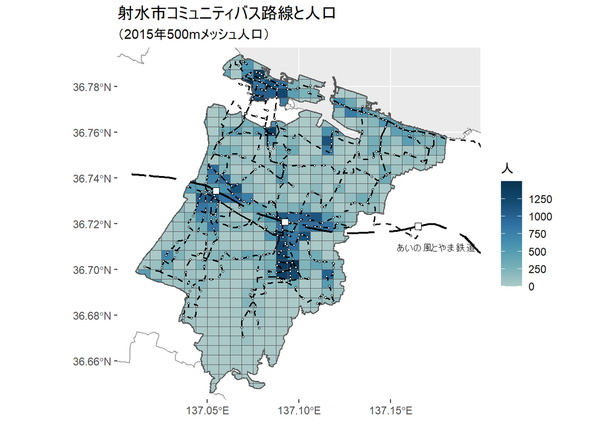

```r
#人口の間隔
my_breaks<-c(0, 250, 500, 750, 1000, 1250)

#可視化
ggplot()+
  geom_sf(data=Toyama_map, fill="white")+
  Imizu+
  geom_sf(data=Imizu_mesh_pop,
          aes(fill=人口総数))+
  scale_fill_met_c("Hokusai2",
                   breaks=my_breaks)+
  Ainokaze_railway+
  Imizu_bus+
  Imizu_busstop+
  annotate("point", x=137.0923306, y=36.7208275,
           fill="white", size=2.5, shape=22)+
  annotate("point", x=137.0547234, y=36.734352,
           fill="white", size=2.5, shape=22)+
  annotate("point", x=137.1648832, y=36.7188936,
           fill="white", size=2.5, shape=22)+
  geom_text(aes(x=137.175, y=36.71), size=3,
              label="あいの風とやま鉄道")+
  coord_sf(xlim=c(137.01, 137.19), ylim=c(36.65, 36.79))+
  labs(fill="人", x="", y="")+
  ggtitle("射水市コミュニティバス路線と人口",
  subtitle="（2015年500mメッシュ人口）")
```

**凡例**

凡例がわかりづらいため，修正.

- パイプ演算子（`%>%`）を使い`Imizu_mesh_pop`に新しい変数「人口総数2」を作成（`mutate`）し，改めて`Imizushi_mesh_pop2`と名付ける．
  - `case_when()`を利用して，条件に合致した値を言葉に置き換えられる（条件式~“変更名称”）．それ以外は`TRUE`．
  - `factor`以降は順番を指定するための指令．

```r
Imizu_mesh_pop %>%
  mutate(人口総数2=case_when(人口総数<250~"250人（10人／ha）未満",
                             人口総数<500~"500人（20人／ha）未満",
                             人口総数<750~"750人（30人／ha）未満",
                             人口総数<1000~"1000人（40人／ha）未満",
                             TRUE~"1000人（40人／ha）以上"),
         人口総数2=factor(人口総数2,
                          levels=c("250人（10人／ha）未満",
                                   "500人（20人／ha）未満",
                                   "750人（30人／ha）未満",
                                   "1000人（40人／ha）未満",
                                   "1000人（40人／ha）以上"))) ->
  Imizu_mesh_pop2
```

**完成図**

- 先ほどまでは`人口総数`が連続変数であったが，`人口総数2`は階層化された離散変数のため`scale_fill_met_d()`を利用して，色付け．

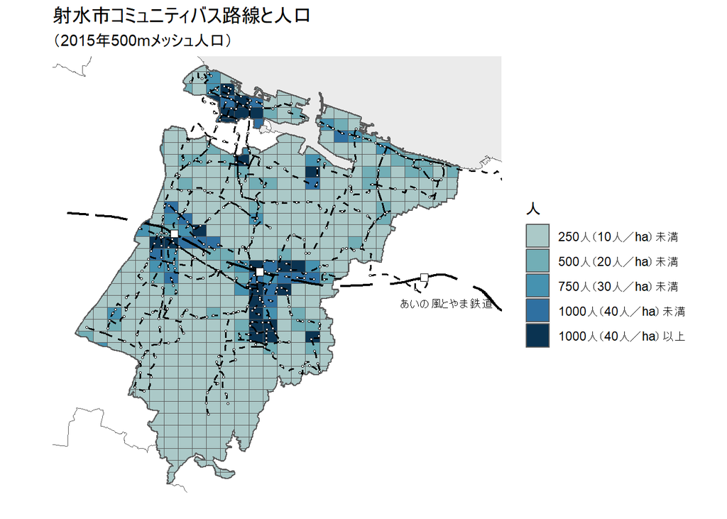

```r
ggplot()+
  geom_sf(data=Toyama_map, fill="white")+
  Imizu+
  geom_sf(data=Imizu_mesh_pop2, aes(fill=人口総数2))+
  scale_fill_met_d("Hokusai2")+
  Ainokaze_railway+
  Imizu_bus+
  Imizu_busstop+
  annotate("point", x=137.0923306, y=36.7208275,
           fill="white", size=2.5, shape=22)+
  annotate("point", x=137.0547234, y=36.734352,
           fill="white", size=2.5, shape=22)+
  annotate("point", x=137.1648832, y=36.7188936,
           fill="white", size=2.5, shape=22)+
  geom_text(aes(x=137.175, y=36.71), size=3,
              label="あいの風とやま鉄道")+
  coord_sf(xlim=c(137.01, 137.19), ylim=c(36.65, 36.79),
           datum=NA)+
  labs(fill="人", x="", y="")+
  ggtitle("射水市コミュニティバス路線と人口",
  subtitle="（2015年500mメッシュ人口）")
```

# 5 応用例 （250mメッシュ）

[統計地理情報システム](https://www.e-stat.go.jp/gis)には5次メッシュ（250mメッシュ）も用意されている．

- 500mメッシュの代わりに250mメッシュによって表現．
  - 色付けは`Hokusai3`．
  - **注意**：PCによっては情報量が増えるためデータ処理に時間・負荷がかかる．
- コードは繰り返しのため，非表示．

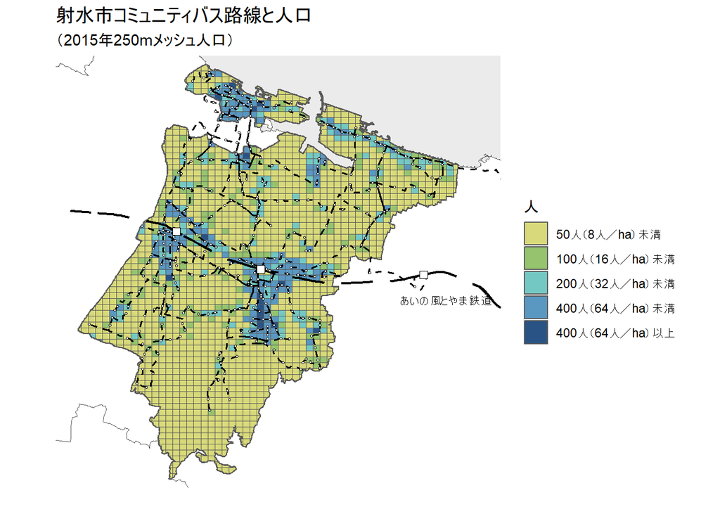

**Rによる地理空間データの可視化**

- チュートリアル[ホーム](https://shinichiro-iwata.github.io/geospatial-data-visualization/)
[^1]: 2024/03/25（改定日現在）2011年（平成23年）のほか2022年（令和4年）も用意されている．
[^2]: 2024/03/25（改定日現在）2010年度（平成22年度）のほか2022年度（令和4年度）も用意されている．